# Data visualization

2019-04-24

## References and materials

- Data viz by moderndive: https://moderndive.com/3-viz.html
- Fundamentals of data visualization: https://serialmentor.com/dataviz/
- Interactive animations: https://plotly-r.com/
- Top 50 visualization with R: http://r-statistics.co/Top50-Ggplot2-Visualizations-MasterList-R-Code.html
- The R graph gallery: https://www.r-graph-gallery.com/
- Cheatsheet

## Needed packages

```r
library(nycflights13)
library(ggplot2)
library(dplyr)
```

## The grammar of graphics

Similarly to a linguistic grammar, “The Grammar of Graphics” (Wilkinson 2005) define a set of rules for constructing statistical graphics by combining different types of layers.

## It’s all about the right question…

There is no rule about which questions you should ask to guide your research.

However, two types of questions will always be useful for making discoveries within your data:

- What type of variation occurs within my variables?
- What type of covariation occurs between my variables?

## What is a variable?

- A **variable** is a quantity, quality, or property that you can measure.
- A **value** is the state of a variable when you measure it. The value of a variable may change from measurement to measurement.
- An **observation** is a set of measurements made under similar conditions.
- **Tabular data** is a set of values, each associated with a variable and an observation.
- Tabular data is **tidy** if each value is placed in its own “cell”, each variable in its own column, and each observation in its own row.

## Tidy data

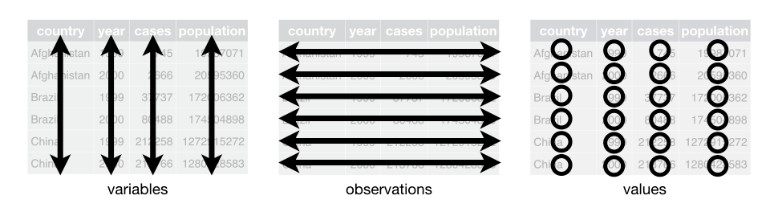

From R for Data Science

## Components of the grammar

In short:

A statistical graphic is a `mapping` of `data` variables to `aes`thetic attributes of geometric objects.

Three essential components:

- `data`: the data set composed of variables that we map.
- `geom`: the geometric object in question. This refers to the type of object we can observe in a plot. For example: points, lines, and bars.
- `aes`: aesthetic attributes of the geometric object. For example, x/y position, color, shape, and size. Each assigned aesthetic attribute can be mapped to a variable in our data set.

## The GapMinder study case

```r
library(tidyverse)
library(gapminder)
ggplot(gapminder, aes(x=gdpPercap, y=lifeExp, col=continent, size=pop))+
        geom_point()
```

[output not shown]

- The data variable GDP per Capita gets mapped to the `x`-position `aes`thetic of the points.
- The data variable Life Expectancy gets mapped to the `y`-position `aes`thetic of the points.
- The data variable Population gets mapped to the `size` `aes`thetic of the points.
- The data variable Continent gets mapped to the `color` `aes`thetic of the points.

## The big 5:

- **scatterplots**: x~y relationships
- **linegraphs**: time series
- **boxplots**: anova, data distribution among factors
- **histograms**: data distribution
- **barplots**: mean values of data

## Scatterplots with `geom_points()`

```r
library(nycflights13)

alaska_flights <- flights %>% filter(carrier == "AS")

ggplot(data = alaska_flights, mapping = aes(x = dep_delay, y = arr_delay)) +
  geom_point()

ggplot(data = alaska_flights, mapping = aes(x = dep_delay, y = arr_delay)) +
  geom_point(alpha = 0.2)

ggplot(data = alaska_flights, mapping = aes(x = dep_delay, y = arr_delay)) +
  geom_jitter(width = 30, height = 30)
```

## Linegraphs with `geom_line`

```r
ggplot(data = weather , mapping = aes(x = time_hour, y = temp)) +
  geom_line()

early_january_weather <- weather %>%
  filter(origin == "EWR" & month == 1 & day <= 15)

ggplot(data = early_january_weather, mapping = aes(x = time_hour, y = temp)) +
  geom_line()
```

## Boxplots via `geom_boxplot()`

```r
ggplot(data = weather, mapping = aes(x = month, y = temp)) +
  geom_boxplot()

ggplot(data = weather, mapping = aes(x = factor(month), y = temp)) +
  geom_boxplot()
```

## Histograms with `geom_histogram()`

```r
ggplot(data = weather, mapping = aes(x = temp)) +
  geom_histogram()


ggplot(data = weather, mapping = aes(x = temp)) +
  geom_histogram(color = "white", fill = "steelblue")

ggplot(data = weather, mapping = aes(x = temp)) +
  geom_histogram(bins = 40, color = "white")
```

## Facets

```r
ggplot(data = weather, mapping = aes(x = temp)) +
  geom_histogram(binwidth = 5, color = "white") +
  facet_wrap(~ month)
```

## A graph

```r
library(tidyverse)
library(gapminder)

sel_contries <- filter(gapminder,
                       country %in%
                         c("Mexico", "Italy", "Chile",
                           "Peru", "Canada", "France"))

lifeExp_plot <- ggplot(data = sel_contries,
                       mapping = aes(x = year, y = lifeExp, color=continent)) +
  geom_line() +
  facet_wrap( ~ country) +
  labs(
    x = "Year",              # x axis title
    y = "Life expectancy",   # y axis title
    title = "Figure 1",      # main title of figure
    color = "Continent"      # title of legend
  ) +
  theme(axis.text.x = element_text(angle = 90, hjust = 1))
```

## How to save plots `ggsave()`

```r
ggsave(filename = "figs/lifeExp.png",
       plot = lifeExp_plot,
       width = 12,
       height = 10,
       dpi = 300,
       units = "cm")
```

Or you can create a ppt directly:

```r
esquisse:::ggplot_to_ppt()# this is awesomeeee
```

## Cool addins

```r
esquisse::esquisser()

colourpicker:::colourPickerAddin()

colourpicker:::plotHelperAddin()
```

## Exercises

## Test yourself

- Use GapMinder data to see how life expectancy changed over time

## Fishing effort exercise

- Find which **region** has the highest mean fishing effort in the Gulf
- Find which **site** has the highest mean fishing effort in the Gulf
- Which **site** has the lowest mean fishing effort?
- Find which **region** has the highest standard deviation in fishing effort in the Gulf
- Find which **site** has the highest number of pangas inside the highest **region** for fishing effort